# Estudios de Informática, Multimedia y Telecomunicaciones

### 3.0.39 LP

```r
summary(datos$LP_CustomerPayments)
```

```
##     Min.  1st Qu.   Median     Mean  3rd Qu.     Max.
##    -2.35  1007.05  2602.14  4212.16  5590.63 38206.09
```

```r
summary(datos$LP_CustomerPrincipalPayments)
```

```
##    Min. 1st Qu.  Median    Mean 3rd Qu.    Max.
##     0.0   502.6  1606.3  3137.8  4000.0 35000.0
```

```r
summary(datos$LP_InterestandFees)
```

```
##     Min.  1st Qu.   Median     Mean  3rd Qu.     Max.
##    -2.35   275.85   703.38  1074.34  1455.57 14329.49
```

```r
summary(datos$LP_ServiceFees)
```

```
##    Min. 1st Qu.  Median    Mean 3rd Qu.    Max.
## -664.87  -74.03  -34.91  -55.23  -14.05   32.06
```

```r
summary(datos$LP_CollectionFees)
```

```
##     Min.  1st Qu.   Median     Mean  3rd Qu.     Max.
## -9274.75     0.00     0.00   -14.18     0.00     0.00
```

```r
summary(datos$LP_GrossPrincipalLoss)
```

```
##    Min. 1st Qu.  Median    Mean 3rd Qu.    Max.
##   -94.2     0.0     0.0   681.9     0.0 25000.0
```

```r
summary(datos$LP_NetPrincipalLoss)
```

```
##    Min. 1st Qu.  Median    Mean 3rd Qu.    Max.
##  -954.5     0.0     0.0   662.8     0.0 25000.0
```

```r
summary(datos$LP_NonPrincipalRecoverypayments)
```

```
##     Min.  1st Qu.   Median     Mean  3rd Qu.     Max.
##     0.00     0.00     0.00    25.35     0.00 21117.90
```

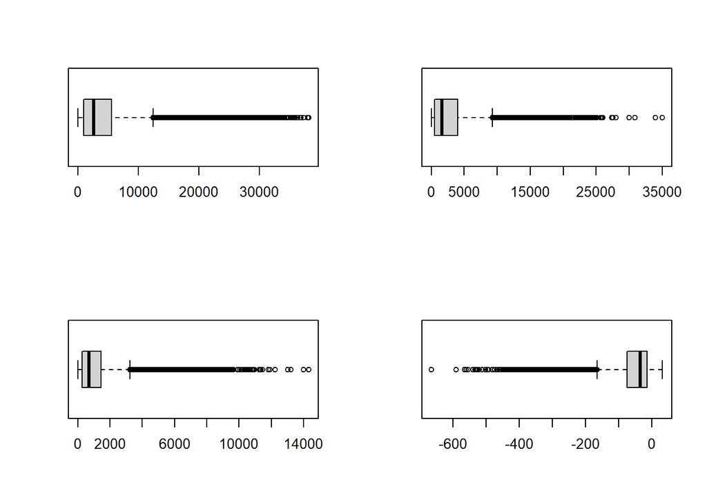

```r
par(mfrow=c(2,2))
boxplot(datos$LP_CustomerPayments, horizontal = T)
boxplot(datos$LP_CustomerPrincipalPayments, horizontal = T)
boxplot(datos$LP_InterestandFees, horizontal = T)
boxplot(datos$LP_ServiceFees, horizontal = T)
```

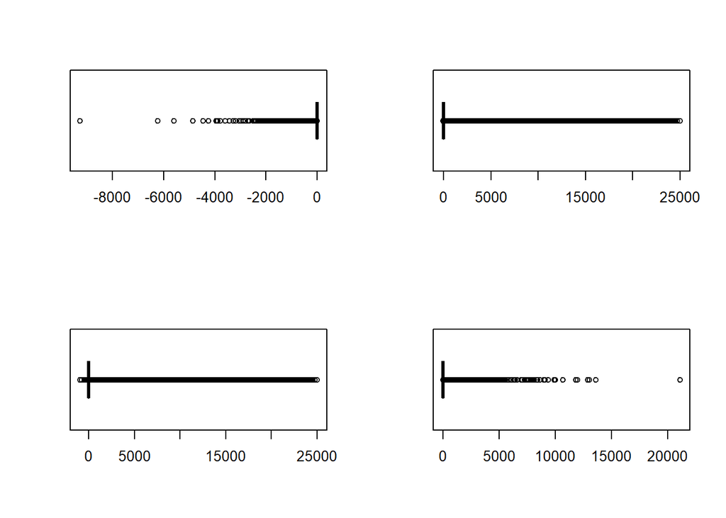

```r
par(mfrow=c(2,2))
boxplot(datos$LP_CollectionFees, horizontal = T)
boxplot(datos$LP_GrossPrincipalLoss, horizontal = T)
boxplot(datos$LP_NetPrincipalLoss, horizontal = T)
boxplot(datos$LP_NonPrincipalRecoverypayments, horizontal = T)
```

Las variables anteriores se refieren a los diferentes parámetros que catacterizan los préstamos del dataset a analizar.

No existen valores vacíos.

Comprobamos la relación entre estas variables, conociendo de antemano alguna de ellas, por ejemplo *LP_CostumerPayments = LP_CostumerPrincipalPayments + LP_InterestsAndFees*.

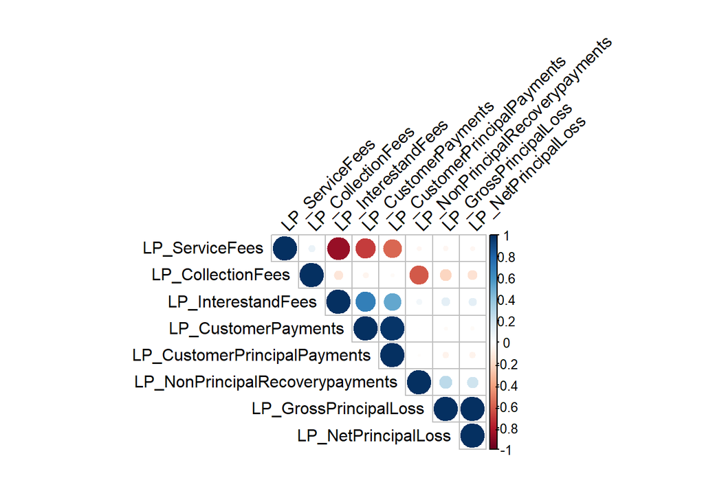

```r
library(corrplot)
#diagrama de correlación
corrplot(cor(datos[,37:44]), type = "upper", order = "hclust",
         tl.col = "black", tl.srt = 45, na.omit=T)
```

Además de la relación como ejemplo, destaca: - LP_ServiceFees vs LP_InterestandFees - LP_GrossPrincipalLoss VS LP_NetPrincipalLoss

De momento no se va a eliminar ninguna de estas varaibles.

### 3.0.40 PercentFunded

```r
summary(datos$PercentFunded)
```

```
##    Min. 1st Qu.  Median    Mean 3rd Qu.    Max.
##  0.7000  1.0000  1.0000  0.9986  1.0000  1.0125
```

Se comprueba que la mayoría de los préstamos está financiado al 100%.

Se observa que el valor máximo está por encima del 100%, hay que corregir ese valor.

```r
datos$PercentFunded[datos$PercentFunded>1]<-1
```

### 3.0.41 Investors

```r
summary(datos$Investors)
```

```
##    Min. 1st Qu.  Median    Mean 3rd Qu.    Max.
##    1.00    2.00   44.00   81.66  117.00 1189.00
```

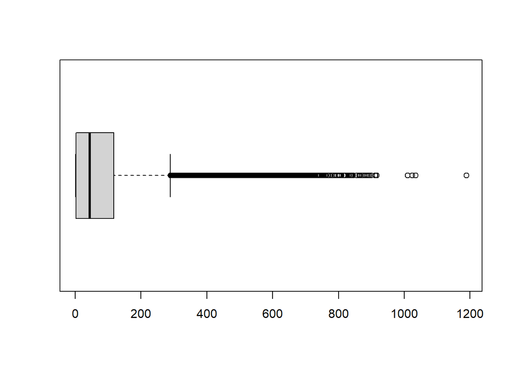

```r
boxplot(datos$Investors, horizontal = T)
```

### 3.0.42 ProsperRating

```r
summary(datos$ProsperRating)
```

```
##           A    AA     B     C     D     E    HR  NA's
## 20656 14525  5996 15722 18230 14085  9438  6580    36
```

```r
datos$ProsperRating[datos$ProsperRating==""]<-NA
```

Dejamos pendientes tratar los valores vacíos.

### 3.0.43 ListingCategory

```r
summary(datos$ListingCategory)
```

```
##     0     1     2     3     4     5     6     7     8     9    10    11    12
## 16508 54605  6958  5210  2287   616  2364  9538   191    83    82   201    46
##    13    14    15    16    17    18    19    20
##  1788   806  1405   289    50   787   722   732
```

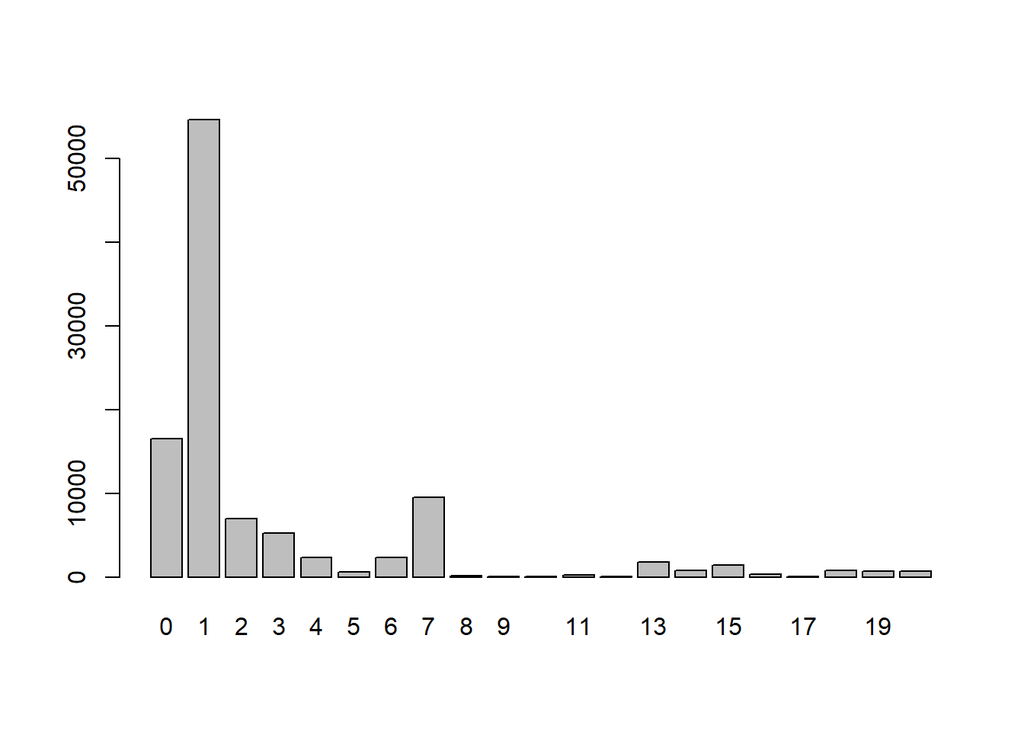

```r
plot(datos$ListingCategory)
```

## 3.1 ¿Los datos contienen ceros o elementos vacíos? ¿Cómo gestionarías cada uno de estos casos?

La mayoría de valores vacíos se han corregido durante el tratamiento individual de cada una de las variables. Quedando algunas para este apartado.

```r
sapply(datos, function(x) sum(is.na(x)))
```

```
##                ListingCreationDate                               Term
##                                  0                                  0
##                         LoanStatus                         ClosedDate
##                                  0                                  0
##                        BorrowerAPR            EstimatedEffectiveYield
##                                  0                              27813
##                       ProsperScore                      BorrowerState
##                              20692                                  0
##                         Occupation                   EmploymentStatus
##                                  0                                  0
##           EmploymentStatusDuration                IsBorrowerHomeowner
##                                  0                                  0
##              CreditScoreRangeLower              CreditScoreRangeUpper
##                                578                                578
##            FirstRecordedCreditLine                    OpenCreditLines
##                                674                                  0
##        OpenRevolvingMonthlyPayment               InquiriesLast6Months
##                                  0                                  0
##                     TotalInquiries               CurrentDelinquencies
##                                  0                                  0
##                   AmountDelinquent          PublicRecordsLast12Months
##                                  0                                  0
##             RevolvingCreditBalance                BankcardUtilization
##                                  0                                  0
##            AvailableBankcardCredit                        TotalTrades
##                                  0                                  0
## TradesNeverDelinquent..percentage.            TradesOpenedLast6Months
##                                  0                                  0
##                  DebtToIncomeRatio                StatedMonthlyIncome
##                                  0                                  0
##                  TotalProsperLoans              OnTimeProsperPayments
##                                  0                                  0
##        ProsperPrincipalOutstanding          LoanCurrentDaysDelinquent
##                                  0                                  0
##                 LoanOriginalAmount                 MonthlyLoanPayment
##                                  0                                  0
##                LP_CustomerPayments       LP_CustomerPrincipalPayments
##                                  0                                  0
##                 LP_InterestandFees                     LP_ServiceFees
##                                  0                                  0
##                  LP_CollectionFees              LP_GrossPrincipalLoss
##                                  0                                  0
##                LP_NetPrincipalLoss    LP_NonPrincipalRecoverypayments
##                                  0                                  0
##                      PercentFunded                          Investors
##                                  0                                  0
##                      ProsperRating                    ListingCategory
##                              20692                                  0
```

- ProsperScore
- CreditScoreRangeLower
- CreditScoreRangeUpper
- EstimatedEffectiveYield
- ProsperRating
- FirstRecordedCreditLine

En el caso de esta última y tal y como se indicó, no es posible asignar un valor, ya que la razón es que esos solicitantes nunca han presentado líneas de crédito.

```r
sapply(datos, function(x) sum(x == ''))
```

```
##                ListingCreationDate                               Term
##                                 NA                                  0
##                         LoanStatus                         ClosedDate
##                                  0                                 NA
##                        BorrowerAPR            EstimatedEffectiveYield
##                                  0                                 NA
##                       ProsperScore                      BorrowerState
##                                 NA                               5384
##                         Occupation                   EmploymentStatus
##                                  0                                  0
##           EmploymentStatusDuration                IsBorrowerHomeowner
##                                  0                                  0
##              CreditScoreRangeLower              CreditScoreRangeUpper
##                                 NA                                 NA
##            FirstRecordedCreditLine                    OpenCreditLines
##                                 NA                                  0
##        OpenRevolvingMonthlyPayment               InquiriesLast6Months
##                                  0                                  0
##                     TotalInquiries               CurrentDelinquencies
##                                  0                                  0
##                   AmountDelinquent          PublicRecordsLast12Months
##                                  0                                  0
##             RevolvingCreditBalance                BankcardUtilization
##                                  0                                  0
##            AvailableBankcardCredit                        TotalTrades
##                                  0                                  0
## TradesNeverDelinquent..percentage.            TradesOpenedLast6Months
##                                  0                                  0
##                  DebtToIncomeRatio                StatedMonthlyIncome
##                                  0                                  0
##                  TotalProsperLoans              OnTimeProsperPayments
##                                  0                                  0
##        ProsperPrincipalOutstanding          LoanCurrentDaysDelinquent
##                                  0                                  0
##                 LoanOriginalAmount                 MonthlyLoanPayment
##                                  0                                  0
##                LP_CustomerPayments       LP_CustomerPrincipalPayments
##                                  0                                  0
##                 LP_InterestandFees                     LP_ServiceFees
##                                  0                                  0
##                  LP_CollectionFees              LP_GrossPrincipalLoss
##                                  0                                  0
##                LP_NetPrincipalLoss    LP_NonPrincipalRecoverypayments
##                                  0                                  0
##                      PercentFunded                          Investors
##                                  0                                  0
##                      ProsperRating                    ListingCategory
##                                 NA                                  0
```

Observamos que en el caso de las variables tipo String, hay valores vacíos para BorrowerState, pero tal y como se indicó anteriormente no es posible asignar un valor con los datos disponibles.

Corregimos las variables identificadas:

### 3.1.1 EstimatedEffectiveYield

El rendimiento efectivo estimado (EstimatedEffectiveYield) es el rendimiento total que recibe un inversor, en contraste con el rendimiento nominal, que es la tasa de interés establecida de un producto.

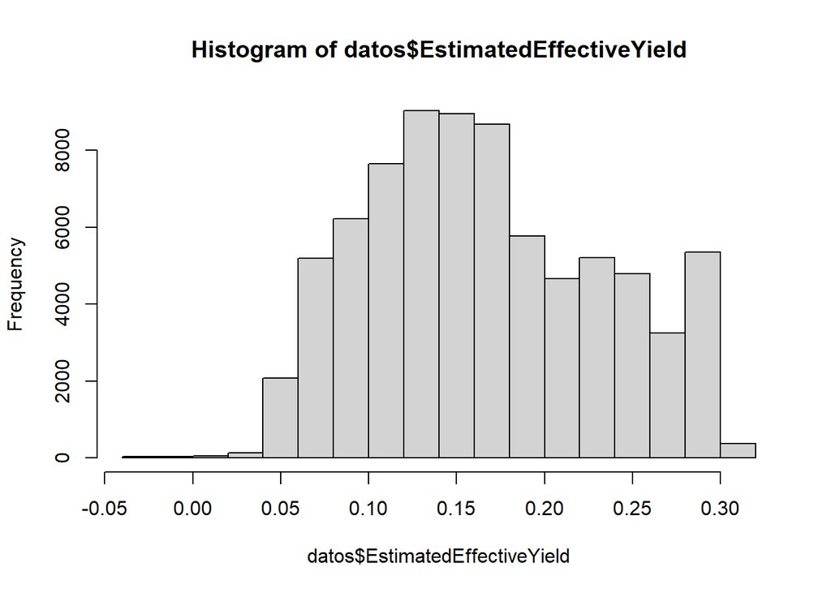

```r
hist(datos$EstimatedEffectiveYield)
```

```r
summary(lm(EstimatedEffectiveYield ~. ,datos,na.action = na.omit))
```

```
##
## Call:
## lm(formula = EstimatedEffectiveYield ~ ., data = datos, na.action = na.omit)
##
## Residuals:
##       Min        1Q    Median        3Q       Max
## -0.296873 -0.005703 -0.000948  0.008281  0.078949
##
## Coefficients: (2 not defined because of singularities)
##                                                Estimate Std. Error t value
## (Intercept)                                  -2.638e-01  1.048e-02 -25.176
## ListingCreationDate                           1.875e-05  4.718e-07  39.746
## Term                                          4.710e-04  1.153e-05  40.841
## LoanStatusCompleted                          -2.510e-02  8.418e-04 -29.823
## LoanStatusCurrent                            -1.716e-02  8.116e-04 -21.139
## LoanStatusDefaulted                          -8.696e-03  8.871e-04  -9.803
## LoanStatusFinalPaymentInProgress             -1.681e-02  1.798e-03  -9.348
## LoanStatusPast Due                           -1.023e-02  9.227e-04 -11.085
## ClosedDate                                    1.391e-07  8.847e-08   1.573
## BorrowerAPR                                   7.949e-01  4.730e-03 168.062
## ProsperScore                                  1.081e-04  6.156e-05   1.755
## BorrowerStateAL                              -3.715e-04  1.936e-03  -0.192
## BorrowerStateAR                               6.128e-04  2.002e-03   0.306
## BorrowerStateAZ                              -5.496e-05  1.922e-03  -0.029
## BorrowerStateCA                              -3.428e-04  1.832e-03  -0.187
## BorrowerStateCO                              -8.967e-04  1.904e-03  -0.471
## BorrowerStateCT                               9.796e-04  1.914e-03   0.512
## BorrowerStateDC                               1.063e-03  2.209e-03   0.481
## BorrowerStateDE                              -6.790e-04  2.287e-03  -0.297
## BorrowerStateFL                               5.356e-04  1.846e-03   0.290
## BorrowerStateGA                              -7.424e-04  1.862e-03  -0.399
## BorrowerStateHI                              -6.472e-04  2.212e-03  -0.293
## BorrowerStateID                              -9.746e-04  2.165e-03  -0.450
## BorrowerStateIL                              -4.413e-04  1.852e-03  -0.238
## BorrowerStateIN                              -3.101e-04  1.905e-03  -0.163
## BorrowerStateKS                               9.516e-04  1.982e-03   0.480
## BorrowerStateKY                              -3.904e-04  1.977e-03  -0.197
## BorrowerStateLA                              -8.250e-04  1.984e-03  -0.416
## BorrowerStateMA                               2.524e-04  1.895e-03   0.133
## BorrowerStateMD                               4.573e-04  1.882e-03   0.243
```

[output cut: 343 more lines]

```
## ListingCategory13                            0.034307 *
## ListingCategory14                            0.004005 **
## ListingCategory15                            0.017766 *
## ListingCategory16                            0.037494 *
## ListingCategory17                            0.061496 .
## ListingCategory18                            0.025222 *
## ListingCategory19                            0.022607 *
## ListingCategory20                            0.016267 *
## ---
## Signif. codes:  0 '***' 0.001 '**' 0.01 '*' 0.05 '.' 0.1 ' ' 1
##
## Residual standard error: 0.02214 on 77267 degrees of freedom
##   (27813 observations deleted due to missingness)
## Multiple R-squared:  0.8912, Adjusted R-squared:  0.891
## F-statistic:  3386 on 187 and 77267 DF,  p-value: < 2.2e-16
```

```r
reg.lin.eey<-lm(EstimatedEffectiveYield ~Term+LoanStatus+BorrowerAPR+ProsperRating ,datos, na.action = na.omit)

summary(reg.lin.eey)
```

```
##
## Call:
## lm(formula = EstimatedEffectiveYield ~ Term + LoanStatus + BorrowerAPR +
##     ProsperRating, data = datos, na.action = na.omit)
##
## Residuals:
##       Min        1Q    Median        3Q       Max
## -0.305458 -0.003844 -0.001295  0.012032  0.043390
##
## Coefficients:
##                                    Estimate Std. Error t value Pr(>|t|)
## (Intercept)                      -5.105e-02  8.775e-04 -58.175  < 2e-16 ***
## Term                              5.285e-04  8.357e-06  63.240  < 2e-16 ***
## LoanStatusCompleted              -8.601e-03  4.356e-04 -19.746  < 2e-16 ***
## LoanStatusCurrent                 6.445e-03  4.157e-04  15.504  < 2e-16 ***
## LoanStatusDefaulted              -4.955e-03  9.387e-04  -5.279 1.30e-07 ***
## LoanStatusFinalPaymentInProgress  9.721e-03  1.895e-03   5.129 2.92e-07 ***
## LoanStatusPast Due                1.170e-02  7.064e-04  16.567  < 2e-16 ***
## BorrowerAPR                       8.950e-01  4.530e-03 197.587  < 2e-16 ***
## ProsperRatingAA                   1.500e-02  4.730e-04  31.705  < 2e-16 ***
## ProsperRatingB                   -4.543e-03  3.660e-04 -12.415  < 2e-16 ***
## ProsperRatingC                   -8.949e-03  4.907e-04 -18.237  < 2e-16 ***
## ProsperRatingD                   -1.113e-02  7.038e-04 -15.815  < 2e-16 ***
## ProsperRatingE                   -1.563e-02  9.253e-04 -16.886  < 2e-16 ***
## ProsperRatingHR                  -2.944e-02  1.054e-03 -27.920  < 2e-16 ***
## ---
## Signif. codes:  0 '***' 0.001 '**' 0.01 '*' 0.05 '.' 0.1 ' ' 1
##
## Residual standard error: 0.02548 on 77441 degrees of freedom
##   (27813 observations deleted due to missingness)
## Multiple R-squared:  0.8556, Adjusted R-squared:  0.8556
## F-statistic: 3.53e+04 on 13 and 77441 DF,  p-value: < 2.2e-16
```

```r
datos$EstimatedEffectiveYield[is.na(datos$EstimatedEffectiveYield)]<-predict(reg.lin.eey)

remove(reg.lin.eey)

summary(datos$EstimatedEffectiveYield)
```

```
##    Min. 1st Qu.  Median    Mean 3rd Qu.    Max.
## -0.0345  0.1161  0.1587  0.1667  0.2172  0.3199
```

### 3.1.2 CreditScoreRangeLower

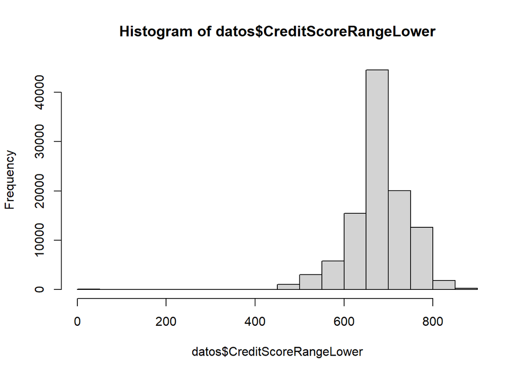

```r
hist(datos$CreditScoreRangeLower)
```

```r
summary(lm(CreditScoreRangeLower~.,datos,na.action = na.omit))
```

```
##
## Call:
## lm(formula = CreditScoreRangeLower ~ ., data = datos, na.action = na.omit)
##
## Residuals:
##        Min         1Q     Median         3Q        Max
## -5.580e-10 -5.000e-12  1.000e-12  6.000e-12  1.133e-07
##
## Coefficients: (1 not defined because of singularities)
##                                                Estimate Std. Error    t value
## (Intercept)                                  -1.900e+01  3.032e-10 -6.266e+10
## ListingCreationDate                           6.945e-15  6.604e-15  1.052e+00
## Term                                          7.823e-16  2.018e-13  4.000e-03
## LoanStatusChargedoff                          2.570e-11  2.773e-10  9.300e-02
## LoanStatusCompleted                           1.222e-11  2.771e-10  4.400e-02
## LoanStatusCurrent                             9.498e-12  2.771e-10  3.400e-02
## LoanStatusDefaulted                           7.184e-12  2.772e-10  2.600e-02
## LoanStatusFinalPaymentInProgress              9.500e-12  2.786e-10  3.400e-02
## LoanStatusPast Due                            1.172e-11  2.773e-10  4.200e-02
## ClosedDate                                   -3.362e-17  1.555e-15 -2.200e-02
## BorrowerAPR                                   7.161e-11  4.949e-11  1.447e+00
## EstimatedEffectiveYield                      -1.061e-10  4.291e-11 -2.473e+00
## ProsperScore                                 -7.248e-14  1.002e-12 -7.200e-02
## BorrowerStateAK                               2.618e-11  3.414e-11  7.670e-01
## BorrowerStateAL                               2.462e-11  1.811e-11  1.360e+00
## BorrowerStateAR                               2.409e-11  2.042e-11  1.179e+00
## BorrowerStateAZ                               2.376e-11  1.761e-11  1.349e+00
## BorrowerStateCA                               2.512e-11  1.468e-11  1.710e+00
## BorrowerStateCO                               8.844e-11  1.716e-11  5.155e+00
## BorrowerStateCT                               2.725e-11  1.777e-11  1.533e+00
## BorrowerStateDC                               2.736e-11  2.595e-11  1.054e+00
## BorrowerStateDE                               2.634e-11  2.802e-11  9.400e-01
## BorrowerStateFL                               2.487e-11  1.531e-11  1.625e+00
## BorrowerStateGA                               2.220e-11  1.562e-11  1.421e+00
## BorrowerStateHI                               2.747e-11  2.616e-11  1.050e+00
## BorrowerStateIA                              -2.148e-12  5.882e-11 -3.700e-02
## BorrowerStateID                               2.433e-11  2.399e-11  1.014e+00
## BorrowerStateIL                               2.394e-11  1.543e-11  1.552e+00
## BorrowerStateIN                               2.413e-11  1.729e-11  1.396e+00
## BorrowerStateKS                               2.286e-11  1.959e-11  1.167e+00
```

[output cut: 359 more lines]

```
## ListingCategory13                            0.001423 **
## ListingCategory14                            0.006731 **
## ListingCategory15                            0.002073 **
## ListingCategory16                            0.057979 .
## ListingCategory17                            0.370890
## ListingCategory18                            0.009207 **
## ListingCategory19                            0.008982 **
## ListingCategory20                            0.008744 **
## ---
## Signif. codes:  0 '***' 0.001 '**' 0.01 '*' 0.05 '.' 0.1 ' ' 1
##
## Residual standard error: 3.915e-10 on 84194 degrees of freedom
##   (20877 observations deleted due to missingness)
## Multiple R-squared:      1,  Adjusted R-squared:      1
## F-statistic: 8.119e+24 on 196 and 84194 DF,  p-value: < 2.2e-16
```

Se logra un R2 ajustado perfecto fundamentalmente por la variable complementaria CreditScoreRangeUpper, ya que ambas van de la mano. El problema reside en que los valores vacíos de una coinciden con los valores vacíos de la otra.

```r
tabla.credit <- datos %>%
     group_by(ProsperRating) %>%
     summarise(count = n(),media=mean(CreditScoreRangeLower,na.rm = T))

rownames(tabla.credit)<-levels(tabla.credit$ProsperRating)

for (i in (1:(dim(datos)[1])))
  {
#asignamos a los valoresvacíos
      if  (is.na(datos$CreditScoreRangeLower[i])){
        datos$CreditScoreRangeLower[i]<-as.integer(tabla.credit[which(tabla.credit$ProsperRating==datos$ProsperRating[i]),3])
      }

}

remove(i,tabla.credit)

summary(datos$CreditScoreRangeLower)
```

```
##    Min. 1st Qu.  Median    Mean 3rd Qu.    Max.    NA's
##     0.0   660.0   680.0   684.4   720.0   880.0     419
```

Imputamos valores a alguna de los registros vacíos, sin embargo no logramos rellenar todos. ELiminamos los registros vacíos.

```r
datos<-subset(datos, !(is.na(CreditScoreRangeLower)))
```

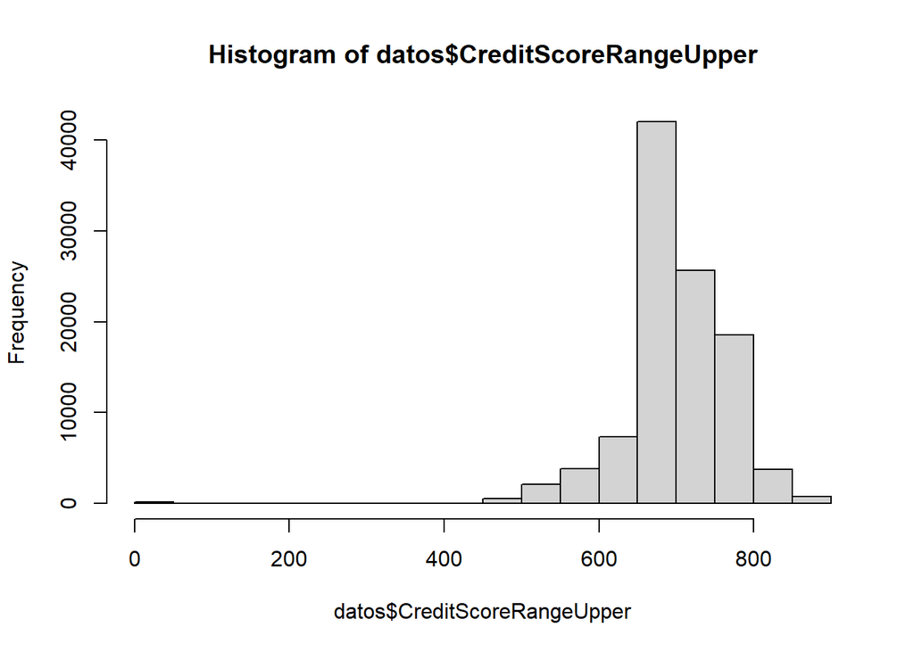

```r
hist(datos$CreditScoreRangeUpper)
```

```r
reg.credit<-lm(CreditScoreRangeUpper~CreditScoreRangeLower,datos,na.action = na.omit)

summary(reg.credit)
```

```
##
## Call:
## lm(formula = CreditScoreRangeUpper ~ CreditScoreRangeLower, data = datos,
##     na.action = na.omit)
##
## Residuals:
##        Min         1Q     Median         3Q        Max
## -9.093e-08  1.000e-12  1.000e-12  1.000e-12  7.000e-12
##
## Coefficients:
##                        Estimate Std. Error   t value Pr(>|t|)
## (Intercept)           1.900e+01  8.969e-12 2.118e+12   <2e-16 ***
## CreditScoreRangeLower 1.000e+00  1.304e-14 7.668e+13   <2e-16 ***
## ---
## Signif. codes:  0 '***' 0.001 '**' 0.01 '*' 0.05 '.' 0.1 ' ' 1
##
## Residual standard error: 2.836e-10 on 104688 degrees of freedom
##   (159 observations deleted due to missingness)
## Multiple R-squared:      1,  Adjusted R-squared:      1
## F-statistic: 5.879e+27 on 1 and 104688 DF,  p-value: < 2.2e-16
```

Se logra un R2 ajustado perfecto fundamentalmente por la variable complementaria CreditScoreRangeUpper, ya que ambas van de la mano. El problema reside en que los valores vacíos de una coinciden con los valores vacíos de la otra.

```r
datos$CreditScoreRangeUpper[is.na(datos$CreditScoreRangeUpper)]<-predict(reg.credit)

remove(reg.credit)
```

### 3.1.4 ProsperScore y ProsperRating

Se tratan de manera conjunta porque presentan valores vacíos en los mismos registros.

```r
summary(datos$ProsperScore)
```

```
##    Min. 1st Qu.  Median    Mean 3rd Qu.    Max.    NA's
##    1.00    4.00    6.00    5.94    8.00   10.00   20273
```

```r
summary(datos$ProsperRating)
```

```
##           A    AA     B     C     D     E    HR  NA's
##     0 14525  5996 15722 18230 14085  9438  6580 20273
```

Planteamos un modelo de regresión lineal para estimar el Score.

```r
summary(lm(ProsperScore~.,datos))
```

```
##
## Call:
## lm(formula = ProsperScore ~ ., data = datos)
##
## Residuals:
##     Min      1Q  Median      3Q     Max
## -8.7954 -0.9227  0.0201  0.8863 18.8063
##
## Coefficients: (2 not defined because of singularities)
##                                                Estimate Std. Error  t value
## (Intercept)                                   2.611e+01  1.038e+00   25.147
## ListingCreationDate                          -1.117e-03  2.238e-05  -49.923
## Term                                          2.523e-03  6.939e-04    3.636
## LoanStatusChargedoff                          1.518e+00  9.533e-01    1.592
## LoanStatusCompleted                           1.277e+00  9.526e-01    1.341
## LoanStatusCurrent                             7.430e-01  9.528e-01    0.780
## LoanStatusDefaulted                           1.377e+00  9.531e-01    1.445
## LoanStatusFinalPaymentInProgress              9.268e-01  9.578e-01    0.968
## LoanStatusPast Due                            8.340e-01  9.533e-01    0.875
## ClosedDate                                    2.475e-05  5.346e-06    4.630
## BorrowerAPR                                   2.655e+00  1.699e-01   15.625
## EstimatedEffectiveYield                      -3.525e+00  1.470e-01  -23.976
## BorrowerStateAK                              -3.051e-02  1.174e-01   -0.260
## BorrowerStateAL                               1.224e-01  6.225e-02    1.966
## BorrowerStateAR                               6.289e-02  7.022e-02    0.896
## BorrowerStateAZ                               7.412e-02  6.056e-02    1.224
## BorrowerStateCA                               1.752e-01  5.048e-02    3.470
## BorrowerStateCO                               1.247e-01  5.899e-02    2.114
## BorrowerStateCT                               1.731e-01  6.110e-02    2.833
## BorrowerStateDC                               2.385e-01  8.922e-02    2.673
## BorrowerStateDE                               1.525e-01  9.635e-02    1.583
## BorrowerStateFL                               1.389e-01  5.263e-02    2.639
## BorrowerStateGA                               1.639e-01  5.371e-02    3.052
## BorrowerStateHI                               1.464e-01  8.994e-02    1.628
## BorrowerStateIA                              -6.409e-01  2.022e-01   -3.170
## BorrowerStateID                              -9.648e-03  8.249e-02   -0.117
## BorrowerStateIL                               1.876e-01  5.304e-02    3.538
## BorrowerStateIN                               1.338e-01  5.943e-02    2.251
## BorrowerStateKS                               2.902e-02  6.736e-02    0.431
## BorrowerStateKY                               8.741e-02  6.780e-02    1.289
```

[output cut: 359 more lines]

```
## ListingCategory13                             < 2e-16 ***
## ListingCategory14                             < 2e-16 ***
## ListingCategory15                             < 2e-16 ***
## ListingCategory16                             < 2e-16 ***
## ListingCategory17                             < 2e-16 ***
## ListingCategory18                             < 2e-16 ***
## ListingCategory19                             < 2e-16 ***
## ListingCategory20                             < 2e-16 ***
## ---
## Signif. codes:  0 '***' 0.001 '**' 0.01 '*' 0.05 '.' 0.1 ' ' 1
##
## Residual standard error: 1.346 on 84195 degrees of freedom
##   (20458 observations deleted due to missingness)
## Multiple R-squared:  0.6479, Adjusted R-squared:  0.6471
## F-statistic: 794.5 on 195 and 84195 DF,  p-value: < 2.2e-16
```

El modelo no alcanza el coeficiente R2 ajustado mínimo para darlo por bueno.

No podemos usar KNN para predecir el Rating. El ordenador no es capaz de procesarlo y da un error de tamaño de vector.

```r
#library(VIM)

#datos$ProsperRating[1:500][datos$ProsperRating[1:500]==""]<-KNN(datos[1:500,])$ProsperRating
```

Eliminamos los valores no procesables.

```r
datos<-subset(datos,!(is.na(datos$ProsperScore)))
summary(datos$ProsperScore)
```

```
##    Min. 1st Qu.  Median    Mean 3rd Qu.    Max.
##    1.00    4.00    6.00    5.94    8.00   10.00
```

```r
datos<-subset(datos,!(datos$ProsperRating==""))
summary(datos$ProsperRating)
```

```
##           A    AA     B     C     D     E    HR
##     0 14525  5996 15722 18230 14085  9438  6580
```

## 3.2 Identificación y tratamiento de valores extremos.

La detección y tratamiento de outliers ya se tratado para cada una de las variables.

En algunos casos, se han corregido, en otros se ha dejado igual. Como se ha indicado, la ausencia de conocimiento con respecto a la realidad del sector y de los préstamos objetivo de análisis dificulta el análisis y la limpieza del dataset.

Antes de continuar procedemos a exportar los datos limpios a CSV.

```r
#escribimos el csv
write.csv(datos,file="datoslimpios.csv")
```

# 4 Análisis de los datos.

Se procede al análisis de los datos.

## 4.1 Selección de los grupos de datos que se quieren analizar/comparar (planificación de los análisis a aplicar).

Como parte de la selección de los datos a analizar, comprobamos como se comporta si aplicamos un PCA.

```r
#convertimos las variables cuantitativas a numerico en base a sus diferentes niveles.
datos.num<-na.omit(scale(sapply(datos , as.numeric)))
PCA<-prcomp(datos.num)

# hacemos el PCA
summary(PCA)
```

```
## Importance of components:
##                           PC1     PC2     PC3     PC4     PC5     PC6     PC7
## Standard deviation     2.4961 2.01374 1.82798 1.65393 1.46468 1.35843 1.32028
## Proportion of Variance 0.1302 0.08472 0.06981 0.05715 0.04482 0.03855 0.03642
## Cumulative Proportion  0.1302 0.21490 0.28471 0.34186 0.38668 0.42524 0.46166
##                            PC8     PC9    PC10    PC11    PC12    PC13    PC14
## Standard deviation     1.27665 1.21727 1.18545 1.10667 1.04126 1.03139 1.00063
## Proportion of Variance 0.03405 0.03096 0.02936 0.02559 0.02265 0.02223 0.02092
## Cumulative Proportion  0.49571 0.52667 0.55603 0.58162 0.60427 0.62649 0.64741
##                           PC15   PC16    PC17    PC18    PC19    PC20    PC21
## Standard deviation     0.99764 0.9858 0.98243 0.96932 0.96228 0.94514 0.90720
## Proportion of Variance 0.02079 0.0203 0.02017 0.01963 0.01935 0.01866 0.01719
## Cumulative Proportion  0.66821 0.6885 0.70868 0.72831 0.74765 0.76632 0.78351
##                           PC22    PC23    PC24    PC25    PC26    PC27    PC28
## Standard deviation     0.89597 0.86394 0.85933 0.84123 0.82123 0.81069 0.78648
## Proportion of Variance 0.01677 0.01559 0.01543 0.01479 0.01409 0.01373 0.01292
## Cumulative Proportion  0.80028 0.81588 0.83131 0.84609 0.86018 0.87391 0.88684
##                           PC29    PC30    PC31    PC32    PC33   PC34    PC35
## Standard deviation     0.73984 0.73327 0.72305 0.68518 0.66154 0.6378 0.62963
## Proportion of Variance 0.01144 0.01123 0.01092 0.00981 0.00914 0.0085 0.00828
## Cumulative Proportion  0.89827 0.90951 0.92043 0.93024 0.93938 0.9479 0.95616
##                           PC36    PC37    PC38    PC39    PC40    PC41   PC42
## Standard deviation     0.61023 0.57159 0.55604 0.53980 0.47127 0.43704 0.4206
## Proportion of Variance 0.00778 0.00683 0.00646 0.00609 0.00464 0.00399 0.0037
## Cumulative Proportion  0.96394 0.97077 0.97723 0.98331 0.98795 0.99195 0.9956
##                           PC43    PC44    PC45    PC46      PC47      PC48
## Standard deviation     0.32977 0.26135 0.16554 0.06435 1.014e-14 8.243e-15
## Proportion of Variance 0.00227 0.00143 0.00057 0.00009 0.000e+00 0.000e+00
## Cumulative Proportion  0.99791 0.99934 0.99991 1.00000 1.000e+00 1.000e+00
```

```r
remove(PCA)
```

Observamos como para lograr alcanzar un nivel en el que expliquemos el 70% de la varianza del dataset original necesitamos emplear 17 componentes. Si queremos llegar al 85% necesitaríamos 26 componentes.

Es decir, el PCA podría ser útil para reducir la dimensionalidad del dataset, pero no se consigue una reducción radical.

En este caso, no tiene sentido representar gráficamente las dos primeras componentes del PCA porque la varianza que explican entre las dos es del 21,5% y por el tamaño del dataset sería complicado observar nanda.

Para la realización de los diversos análisis se trabajará con el dataset completo que hemos limpiado y preparado, haciendo los ajustes que sean necesarios para los métodos que se planteen.

## 4.2 Comprobación de la normalidad y homogeneidad de la varianza.

Para la comprobación de que los valores que toman las variables provienen de una población distribuida normalmente, se utiliza la prueba de normalidad de Anderson-Darling.

Así, se comprueba que para que cada prueba se obtiene un p-valor superior al nivel de significación prefijado α = 0, 05. Si esto se cumple, entonces se considera que variable en cuestión sigue una distribución normal.

```r
datos.normales<-function(datos){

  library(nortest)
  alpha = 0.05
  col.names = colnames(datos)
  for (i in 1:ncol(datos)) {
  if (i == 1) cat("Variables que no siguen una distribución normal:\n")
  if (is.integer(datos[,i]) | is.numeric(datos[,i])) {
  p_val = ad.test(datos[,i])$p.value
  if (p_val < alpha) {
  cat(col.names[i])
  # Format output
  if (i < ncol(datos) - 1) cat(", ")
  if (i %% 3 == 0) cat("\n")
  }
  }
  }
}

datos.normales(datos)
```

```
## Variables que no siguen una distribución normal:
## Term, BorrowerAPR, EstimatedEffectiveYield,
## ProsperScore, EmploymentStatusDuration, CreditScoreRangeLower, CreditScoreRangeUpper, OpenCreditLines, OpenRevolvingMonthlyPayment, InquiriesLast6Months,
## TotalInquiries, CurrentDelinquencies, AmountDelinquent,
## PublicRecordsLast12Months, RevolvingCreditBalance, BankcardUtilization,
## AvailableBankcardCredit, TotalTrades, TradesNeverDelinquent..percentage.,
## TradesOpenedLast6Months, DebtToIncomeRatio, StatedMonthlyIncome,
## TotalProsperLoans, OnTimeProsperPayments, ProsperPrincipalOutstanding,
## LoanCurrentDaysDelinquent, LoanOriginalAmount, MonthlyLoanPayment,
## LP_CustomerPayments, LP_CustomerPrincipalPayments, LP_InterestandFees,
## LP_ServiceFees, LP_CollectionFees, LP_GrossPrincipalLoss,
## LP_NetPrincipalLoss, LP_NonPrincipalRecoverypayments, PercentFunded,
## Investors,
```

```r
remove(datos.normales)
```

Se comprueba que ninguna de las variables presenta una distribución normal.

Para la comprobación de la homogeneidad de varianzas entre varios grupos, existen diversos métodos:

- Prueba F: Compare las varianzas de dos muestras. Los datos deben distribuirse normalmente.
- Prueba de Bartlett: compare las varianzas de k muestras, donde k puede ser más de dos muestras. Los datos deben distribuirse normalmente. La prueba de Levene es una alternativa a la prueba de Bartlett que es menos sensible a las desviaciones de la normalidad.
- Prueba de Levene: compare las varianzas de k muestras, donde k puede ser más de dos muestras. Es una alternativa a la prueba de Bartlett que es menos sensible a las desviaciones de la normalidad.
- Test de Fligner-Killeen: test no paramétrico muy robusto frente a desviaciones de la normalidad.

Descartamos los dos primeros test, por disponer de datos que no se distribuyen de manera normal. Usamos Fligner-Killeen por ser uno de los test más robustos para distribuciones no normales. Analizaremos el valor de préstamo solicitado contra el estado del préstamo.

```r
fligner.test(LoanOriginalAmount ~ LoanStatus, data = datos)
```

```
##
##  Fligner-Killeen test of homogeneity of variances
##
## data:  LoanOriginalAmount by LoanStatus
## Fligner-Killeen:med chi-squared = 3999.2, df = 6, p-value < 2.2e-16
```

Rechazamos la hipótesis nula, por lo que al menos dos de los grupos presentan varianzas diferentes.

Adicionalmente, realizaremos un ANOVA para analizar el comprotamiento de la media de los préstamos solicitados respecto a los diferentes grupos de la variable de estado. Si bien hay que destacar que la varianza dentro de los grupos debería de ser aproximadamente igual en todos ellos. Esto es así ya que en la hipótesis nula se considera que todas las observaciones proceden de la misma población, por lo que tienen la misma media y también la misma varianza.

```r
summary(aov(LoanOriginalAmount ~ LoanStatus, data = datos))
```

```
##                Df    Sum Sq   Mean Sq F value Pr(>F)
## LoanStatus      6 3.208e+11 5.347e+10    1444 <2e-16 ***
## Residuals   84569 3.130e+12 3.702e+07
## ---
## Signif. codes:  0 '***' 0.001 '**' 0.01 '*' 0.05 '.' 0.1 ' ' 1
```

Como el valor p es menor que el nivel de significancia 0.05, podemos concluir que existen diferencias significativas en la media entre los grupos.

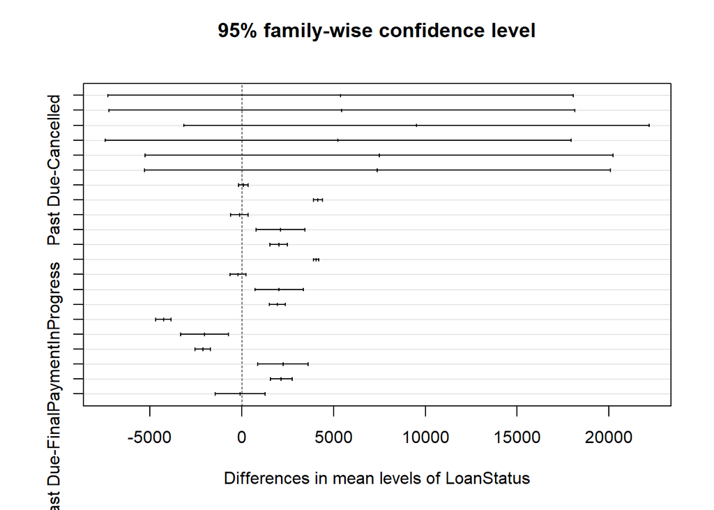

```r
plot(TukeyHSD(aov(LoanOriginalAmount ~ LoanStatus, data = datos)))
```

## 4.3 Aplicación de pruebas estadísticas para comparar los grupos de datos. En función de los datos y el objetivo del estudio, aplicar pruebas de contraste de hipótesis, correlaciones, regresiones, etc. Aplicar al menos tres métodos de análisis diferentes.

### 4.3.1 Método 1. Modelo regresión para conocer como se calcula el ProsperScore

Según explican en su [web](https://www.prosper.com/plp/general-prosper_score/), Se creó una puntuación de riesgo personalizada utilizando datos históricos de Prosper para evaluar el riesgo de las listas de prestatarios de Prosper. A diferencia del score de una agencia de crédito, que se basa en una variedad mucho más amplia de desempeño de préstamos, el puntaje de Prosper se basa específicamente en la población de prestatarios y solicitantes de Prosper. Como tal, el puntaje de la agencia de informes crediticios debe clasificar el riesgo de orden en la población de Prosper. Prosper utiliza conjuntamente la puntuación personalizada y la puntuación de la agencia de informes crediticios para evaluar el nivel de riesgo del prestatario y determinar las tasas de pérdida estimadas.

Las variables clave en el cuadro de mando son:

- Número de consultas al buró de crédito
- Número de cuentas morosas en el buró de crédito
- Utilización de la tarjeta de crédito en el buró de crédito
- Número de operaciones abiertas recientemente en el buró de crédito
- Relación deuda-ingresos
- Rendimiento del pago de préstamos en préstamos anteriores de Prosper

```r
#trabajaremos solo con los prestamos Current
datos.reg<-subset(datos,LoanStatus=="Current")
datos.reg$LoanStatus<-NULL
#tambien eliminamos de partida ProsperRating por presentar una relación bastante directa según se ha comprobado previamente.
datos.reg$ProsperRating<-NULL

summary(lm(ProsperScore~TotalInquiries+InquiriesLast6Months+CurrentDelinquencies+BankcardUtilization+AvailableBankcardCredit+TotalTrades+TradesNeverDelinquent..percentage.+DebtToIncomeRatio+OnTimeProsperPayments,datos.reg))
```

```
##
## Call:
## lm(formula = ProsperScore ~ TotalInquiries + InquiriesLast6Months +
##     CurrentDelinquencies + BankcardUtilization + AvailableBankcardCredit +
##     TotalTrades + TradesNeverDelinquent..percentage. + DebtToIncomeRatio +
##     OnTimeProsperPayments, data = datos.reg)
##
## Residuals:
##      Min       1Q   Median       3Q      Max
## -16.7350  -1.4603   0.0602   1.4271  13.2164
##
## Coefficients:
##                                      Estimate Std. Error t value Pr(>|t|)
## (Intercept)                         6.714e+00  2.342e-01  28.668   <2e-16 ***
## TotalInquiries                     -3.670e-02  2.876e-03 -12.761   <2e-16 ***
## InquiriesLast6Months               -5.401e-01  8.068e-03 -66.946   <2e-16 ***
## CurrentDelinquencies               -9.214e-02  8.609e-03 -10.703   <2e-16 ***
## BankcardUtilization                -1.344e+00  3.440e-02 -39.065   <2e-16 ***
## AvailableBankcardCredit             3.421e-05  5.996e-07  57.061   <2e-16 ***
## TotalTrades                         2.742e-04  8.245e-04   0.333   0.7395
## TradesNeverDelinquent..percentage.  1.195e+00  7.997e-02  14.938   <2e-16 ***
## DebtToIncomeRatio                  -1.310e+00  3.140e-02 -41.725   <2e-16 ***
## OnTimeProsperPayments              -5.556e-01  2.251e-01  -2.468   0.0136 *
## ---
## Signif. codes:  0 '***' 0.001 '**' 0.01 '*' 0.05 '.' 0.1 ' ' 1
##
## Residual standard error: 1.944 on 52424 degrees of freedom
## Multiple R-squared:  0.2636, Adjusted R-squared:  0.2635
## F-statistic:  2085 on 9 and 52424 DF,  p-value: < 2.2e-16
```

```r
model.reg<-lm(ProsperScore~-1+TotalInquiries+InquiriesLast6Months+CurrentDelinquencies+BankcardUtilization+AvailableBankcardCredit+TotalTrades+TradesNeverDelinquent..percentage.+DebtToIncomeRatio+OnTimeProsperPayments,datos.reg)

summary(model.reg)
```

```
##
## Call:
## lm(formula = ProsperScore ~ -1 + TotalInquiries + InquiriesLast6Months +
##     CurrentDelinquencies + BankcardUtilization + AvailableBankcardCredit +
##     TotalTrades + TradesNeverDelinquent..percentage. + DebtToIncomeRatio +
##     OnTimeProsperPayments, data = datos.reg)
##
## Residuals:
##      Min       1Q   Median       3Q      Max
## -16.4555  -1.4679   0.0609   1.4400  13.4636
##
## Coefficients:
##                                      Estimate Std. Error t value Pr(>|t|)
## TotalInquiries                     -3.235e-02  2.895e-03 -11.174  < 2e-16 ***
## InquiriesLast6Months               -5.337e-01  8.128e-03 -65.662  < 2e-16 ***
## CurrentDelinquencies               -6.244e-02  8.613e-03  -7.249 4.24e-13 ***
## BankcardUtilization                -1.289e+00  3.462e-02 -37.224  < 2e-16 ***
## AvailableBankcardCredit             3.334e-05  6.035e-07  55.251  < 2e-16 ***
## TotalTrades                         1.787e-03  8.292e-04   2.155   0.0312 *
## TradesNeverDelinquent..percentage.  1.773e+00  7.799e-02  22.740  < 2e-16 ***
## DebtToIncomeRatio                  -1.304e+00  3.164e-02 -41.224  < 2e-16 ***
## OnTimeProsperPayments               5.555e+00  7.283e-02  76.283  < 2e-16 ***
## ---
## Signif. codes:  0 '***' 0.001 '**' 0.01 '*' 0.05 '.' 0.1 ' ' 1
##
## Residual standard error: 1.959 on 52425 degrees of freedom
## Multiple R-squared:  0.9027, Adjusted R-squared:  0.9027
## F-statistic: 5.403e+04 on 9 and 52425 DF,  p-value: < 2.2e-16
```

Vemos como así el modelo mejora en términos de R2, sin embargo a la hora de realizar la predicción el resultado es malo.

```r
summary(as.integer(predict(model.reg,datos.reg))==datos.reg$ProsperScore)
```

```
##    Mode   FALSE    TRUE
## logical   43817    8617
```

Graficamos ambos resultados:

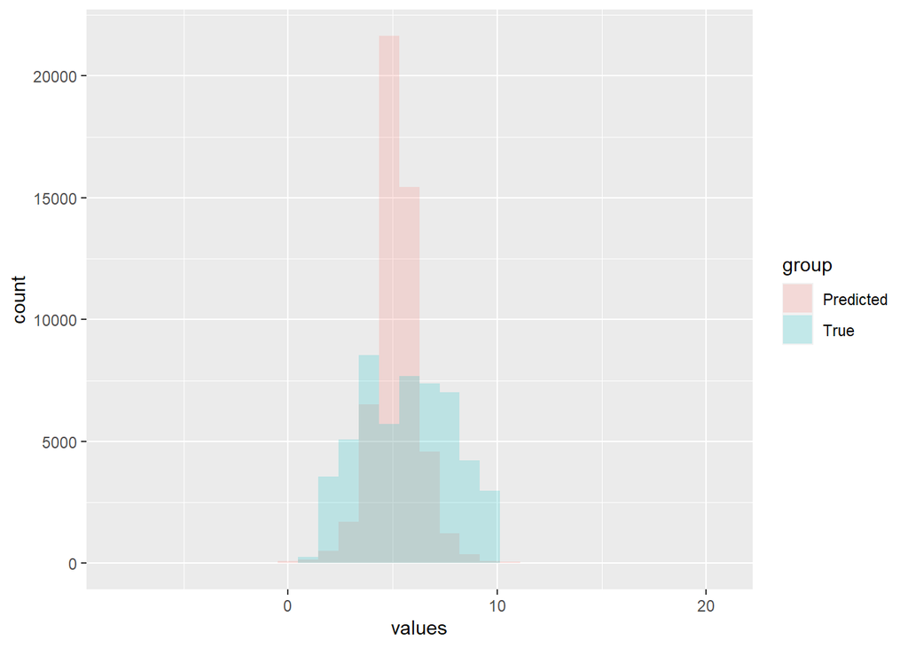

```r
datos.grafica <- data.frame(values = c(as.integer(predict(model.reg,datos.reg)),                    # Create example data
                              datos.reg$ProsperScore),
                   group = c(rep("Predicted", 52434),
                             rep("True", 52434)))

ggplot(datos.grafica, aes(x = values, fill = group)) +                       # Draw overlaying histogram
  geom_histogram(position = "identity", alpha = 0.2, bins = 50 + xlim(0,10))
```

```r
remove(model.reg)
```

Observamos que los modelos únicamente con las variables que reconocen emplear en la web da un resultado pobre.

Observamos como se comporta con un modelo más elaborado:

```r
summary(lm(ProsperScore~., datos.reg))
```

```
##
## Call:
## lm(formula = ProsperScore ~ ., data = datos.reg)
##
## Residuals:
##     Min      1Q  Median      3Q     Max
## -9.7197 -0.9027 -0.0446  0.8737  7.5108
##
## Coefficients: (6 not defined because of singularities)
##                                                Estimate Std. Error t value
## (Intercept)                                   5.847e+01  9.976e-01  58.604
## ListingCreationDate                          -2.597e-03  5.341e-05 -48.622
## Term                                         -2.198e-02  1.088e-03 -20.202
## ClosedDate                                   -1.364e-06  5.414e-06  -0.252
## BorrowerAPR                                  -6.044e+01  1.263e+00 -47.848
## EstimatedEffectiveYield                       4.510e+01  1.538e+00  29.320
## BorrowerStateAL                               1.430e-01  1.437e-01   0.995
## BorrowerStateAR                               8.601e-02  1.474e-01   0.584
## BorrowerStateAZ                               1.009e-01  1.426e-01   0.708
## BorrowerStateCA                               2.385e-01  1.364e-01   1.748
## BorrowerStateCO                               1.317e-01  1.414e-01   0.931
## BorrowerStateCT                               2.383e-01  1.420e-01   1.678
## BorrowerStateDC                               2.881e-01  1.661e-01   1.735
## BorrowerStateDE                               1.893e-01  1.670e-01   1.134
## BorrowerStateFL                               1.197e-01  1.374e-01   0.871
## BorrowerStateGA                               1.845e-01  1.386e-01   1.332
## BorrowerStateHI                               1.562e-01  1.614e-01   0.968
## BorrowerStateID                               6.229e-02  1.608e-01   0.387
## BorrowerStateIL                               2.230e-01  1.378e-01   1.618
## BorrowerStateIN                               8.630e-02  1.416e-01   0.610
## BorrowerStateKS                               1.127e-02  1.467e-01   0.077
## BorrowerStateKY                               5.014e-02  1.467e-01   0.342
## BorrowerStateLA                               6.176e-02  1.467e-01   0.421
## BorrowerStateMA                               2.045e-01  1.408e-01   1.453
## BorrowerStateMD                               9.936e-02  1.400e-01   0.710
## BorrowerStateMI                               1.317e-01  1.393e-01   0.945
## BorrowerStateMN                               8.449e-02  1.415e-01   0.597
## BorrowerStateMO                               1.429e-01  1.418e-01   1.008
## BorrowerStateMS                               1.040e-01  1.493e-01   0.697
## BorrowerStateMT                              -2.839e-02  1.772e-01  -0.160
```

[output cut: 318 more lines]

```
## ListingCategory12                            0.011640 *
## ListingCategory13                            0.012633 *
## ListingCategory14                            0.067927 .
## ListingCategory15                            0.011563 *
## ListingCategory16                            0.003865 **
## ListingCategory17                            0.018449 *
## ListingCategory18                            0.017441 *
## ListingCategory19                            0.013670 *
## ListingCategory20                            0.020493 *
## ---
## Signif. codes:  0 '***' 0.001 '**' 0.01 '*' 0.05 '.' 0.1 ' ' 1
##
## Residual standard error: 1.315 on 52262 degrees of freedom
## Multiple R-squared:  0.6639, Adjusted R-squared:  0.6628
## F-statistic: 603.7 on 171 and 52262 DF,  p-value: < 2.2e-16
```

Comprobamos que el modelo no presenta un coeficiente muy elevado. Lo depuramos al eliminar las variables menos significativas.

```r
model.reg2<-lm(ProsperScore~.-ClosedDate-BorrowerState-Occupation-CreditScoreRangeUpper-EmploymentStatusDuration-AmountDelinquent-PublicRecordsLast12Months-LoanCurrentDaysDelinquent-LP_InterestandFees-LP_GrossPrincipalLoss-LP_NetPrincipalLoss-LP_NonPrincipalRecoverypayments-LP_CollectionFees-PercentFunded  , datos.reg)

summary(model.reg2)
```

```
##
## Call:
## lm(formula = ProsperScore ~ . - ClosedDate - BorrowerState -
##     Occupation - CreditScoreRangeUpper - EmploymentStatusDuration -
##     AmountDelinquent - PublicRecordsLast12Months - LoanCurrentDaysDelinquent -
##     LP_InterestandFees - LP_GrossPrincipalLoss - LP_NetPrincipalLoss -
##     LP_NonPrincipalRecoverypayments - LP_CollectionFees - PercentFunded,
##     data = datos.reg)
##
## Residuals:
##      Min       1Q   Median       3Q      Max
## -11.2049  -0.9048  -0.0447   0.8704   7.6209
##
## Coefficients:
##                                      Estimate Std. Error t value Pr(>|t|)
## (Intercept)                         5.853e+01  9.395e-01  62.305  < 2e-16 ***
## ListingCreationDate                -2.598e-03  5.327e-05 -48.766  < 2e-16 ***
## Term                               -2.231e-02  1.086e-03 -20.540  < 2e-16 ***
## BorrowerAPR                        -6.081e+01  1.262e+00 -48.175  < 2e-16 ***
## EstimatedEffectiveYield             4.542e+01  1.537e+00  29.551  < 2e-16 ***
## EmploymentStatusFull-time          -8.339e-01  4.065e-02 -20.517  < 2e-16 ***
## EmploymentStatusNot employed       -1.347e-01  1.318e+00  -0.102 0.918572
## EmploymentStatusOther              -9.839e-02  2.667e-02  -3.689 0.000225 ***
## EmploymentStatusPart-time          -1.930e+00  3.036e-01  -6.358 2.06e-10 ***
## EmploymentStatusRetired            -6.729e-01  1.502e-01  -4.480 7.47e-06 ***
## IsBorrowerHomeownerTrue            -4.658e-02  1.306e-02  -3.566 0.000363 ***
## CreditScoreRangeLower              -8.948e-03  2.091e-04 -42.801  < 2e-16 ***
## FirstRecordedCreditLine            -1.866e-05  2.324e-06  -8.032 9.79e-16 ***
## OpenCreditLines                    -5.003e-03  1.815e-03  -2.756 0.005850 **
## OpenRevolvingMonthlyPayment         1.262e-04  2.545e-05   4.961 7.05e-07 ***
## InquiriesLast6Months               -2.266e-01  5.864e-03 -38.647  < 2e-16 ***
## TotalInquiries                     -1.556e-02  2.024e-03  -7.687 1.54e-14 ***
## CurrentDelinquencies               -3.188e-02  5.909e-03  -5.395 6.88e-08 ***
## RevolvingCreditBalance             -1.138e-06  2.880e-07  -3.951 7.78e-05 ***
## BankcardUtilization                -4.560e-01  2.842e-02 -16.045  < 2e-16 ***
## AvailableBankcardCredit             1.297e-05  4.661e-07  27.832  < 2e-16 ***
## TotalTrades                        -2.703e-03  7.228e-04  -3.740 0.000184 ***
## TradesNeverDelinquent..percentage. -5.000e-01  6.297e-02  -7.940 2.06e-15 ***
## TradesOpenedLast6Months            -1.991e-01  6.656e-03 -29.910  < 2e-16 ***
## DebtToIncomeRatio                  -1.350e-01  2.249e-02  -6.003 1.95e-09 ***
```

[output cut: 19 more lines]

```
## ListingCategory12                   1.253e+00  4.747e-01   2.639 0.008324 **
## ListingCategory13                   1.029e+00  4.000e-01   2.572 0.010117 *
## ListingCategory14                   7.665e-01  4.019e-01   1.907 0.056506 .
## ListingCategory15                   1.041e+00  4.004e-01   2.599 0.009358 **
## ListingCategory16                   1.215e+00  4.093e-01   2.967 0.003006 **
## ListingCategory17                   1.118e+00  4.596e-01   2.433 0.014983 *
## ListingCategory18                   9.948e-01  4.021e-01   2.474 0.013350 *
## ListingCategory19                   1.023e+00  4.025e-01   2.542 0.011038 *
## ListingCategory20                   9.738e-01  4.022e-01   2.421 0.015475 *
## ---
## Signif. codes:  0 '***' 0.001 '**' 0.01 '*' 0.05 '.' 0.1 ' ' 1
##
## Residual standard error: 1.317 on 52381 degrees of freedom
## Multiple R-squared:  0.6622, Adjusted R-squared:  0.6618
## F-statistic:  1974 on 52 and 52381 DF,  p-value: < 2.2e-16
```

Comprobamos como ha disminuido ampliamente el número de variables, sin embargo el coeficiente R2 ajustado apenas se ha visto afectado.

```r
summary(as.integer(predict(model.reg2,datos.reg))==datos.reg$ProsperScore)
```

```
##    Mode   FALSE    TRUE
## logical   37323   15111
```

Graficamos ambos resultados:

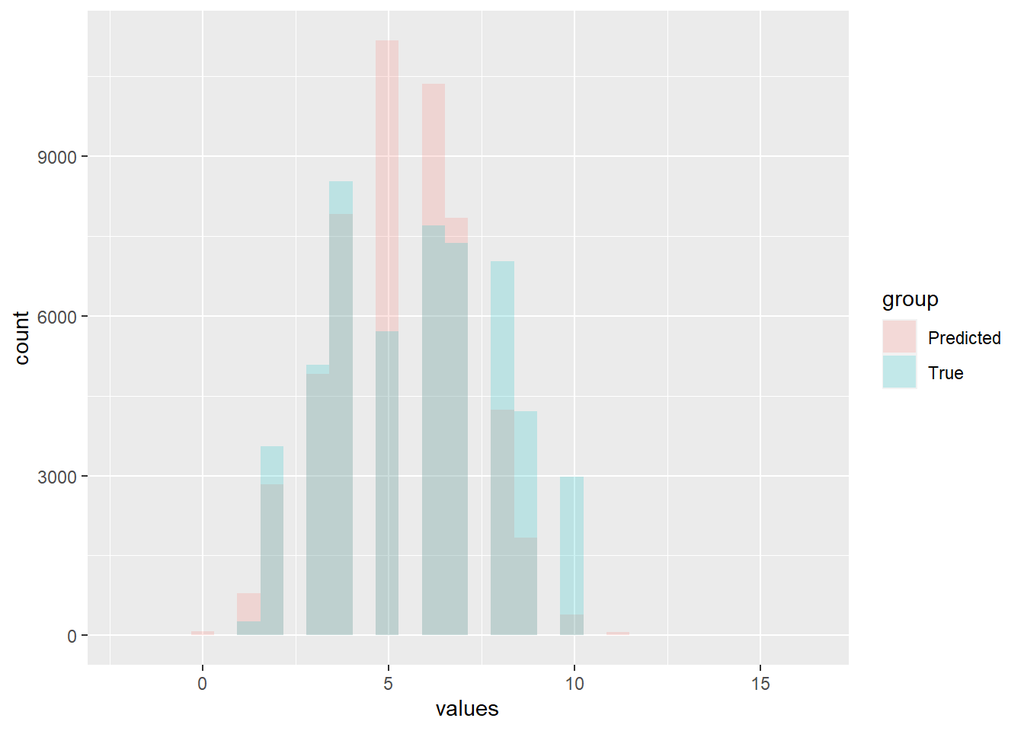

```r
datos.grafica <- data.frame(values = c(as.integer(predict(model.reg2,datos.reg)),                    # Create example data
                              datos.reg$ProsperScore),
                   group = c(rep("Predicted", 52434),
                             rep("True", 52434)))

ggplot(datos.grafica, aes(x = values, fill = group)) +                       # Draw overlaying histogram
  geom_histogram(position = "identity", alpha = 0.2, bins = 50 + xlim(0,10))
```

```r
remove(model.reg2,datos.reg,datos.grafica)
```

Se comprueba que los resultados si bien mejoran respecto al primer modelo, siguen siendo pobres. Si bien una parte del error podría explicarse por el redondeo necesario para aproximar a un número entero los resultados predichos por el modelo, todo parece indicar que mediante un modelo de regresión lineal multivariable no es posible inferir de manera acertada el ProsperScore. Sería necesario desarrollar métodos más complejos.

### 4.3.2 Método 2. Contrastes de hipótesis

Se procede a comparar muestras de los datos para las variables `ProsperScore` y `EmploymentStatus`. Aunque las variables no se distribuyen según una normal, las muestras tienen un tamaño suficientemente grande para asumir normalidad según el Teorema del Límite central.

Se definen las hipótesis nula y alternativa para el caso de comparativa de ProperScore en función del estado de ocupación. Particularmente, se quiere analizar la media de puntuación de prosperidad según si el individuo está, o no, desempleado.

$$H_0: \mu_1 = \mu_2$$
$$H_1: \mu_1 > \mu_2$$

Donde $\mu_1$ se corresponde con la media del ProsperScore para desempleados y $\mu_2$ con la media del ProperScore para no desempleados.

En este caso tenemos dos muestras independientes (`ProsperScore` para dos estados ocupacionales) y se desea realizar un test sobre la media. Se aplicará un test de hipótesis de dos muestras sobre la media correspondiendo con un test unilateral por la derecha.

Se realiza un test de varianza para comprobar si se puede suponer que la varianza de ambas muestras es igual.

```r
var.test(datos$ProsperScore[which(datos$EmploymentStatus=="Not employed")], datos$ProsperScore[which(datos$EmploymentStatus=="Employed")])
```

```
##
##  F test to compare two variances
##
## data:  datos$ProsperScore[which(datos$EmploymentStatus == "Not employed")] and datos$ProsperScore[which(datos$EmploymentStatus == "Employed")]
## F = 0.75425, num df = 32, denom df = 65893, p-value = 0.3212
## alternative hypothesis: true ratio of variances is not equal to 1
## 95 percent confidence interval:
##  0.4877157 1.3196877
## sample estimates:
## ratio of variances
##          0.7542486
```

El resultado de p-value es 0.32, por lo que no podemos descartar la igualdad de varianzas. En consecuencia, se aplica un **test de dos muestras independientes sobre la media con varianzas desconocidas e iguales correspondiendo con un test unilateral por la derecha**.

Por tanto, se pretende contestar a la pregunta de si el ProsperScore medio de los desempleados es igual al ProsperScore medio de los individuos empleados o, por el contrario, es mayor.

```r
test_prosperscore <- t.test(datos$ProsperScore[which(datos$EmploymentStatus=="Not employed")],
                            datos$ProsperScore[which(datos$EmploymentStatus=="Employed")],
                            var.equal=TRUE, alternative="greater")
data.frame(test_prosperscore[c("statistic", "parameter", "p.value")])
```

```
##   statistic parameter   p.value
## t -1.672966     65925 0.9528306
```

```r
remove(test_prosperscore)
```

El p-value es superior al nivel de significación (0.05). Por tanto, con un nivel de confianza del 95%, se puede aceptar la hipótesis nula (igualdad de media de ProsperScore) y se puede concluir que **el promedio de ProsperScore de los individuos empleados es igual que el promedio de ProsperScore de los desempleados**.

### 4.3.3 Método 3. Tree Model para inferir las reglas que permitan identificar si un prestatario será buen pagador o moroso.

Vamos a analizar el árbol que caracteriza a un buen o mal prestatario en base a las variables que definen su perfil financiero. Para ello, cogeremos solo los préstamos que actualmente están en curso.

Basándonos en la variable LoanCurrentDaysDeliquent definiremos una variable secundaria en base a la que responder a la pregunta planteada. Para ello, definiremos un umbral de días; en este caso, lo planteamos para más en base al Term para más de 1/12 se considerará un mal pagador.

En primer lugar, preparamos los dividimos el dataset en una parte para entrenar y otra para validar el modelo. Se seleccionan las variables que se consideran significativas para evitar errores por el tamaño del dataset.

```r
#seleccionamos el subset
datos.tree<-na.omit(subset(datos,(LoanStatus=="Current" | LoanStatus=="Past Due" |  LoanStatus=="Chargedoff")))
datos.tree$tipoPagador<-1
datos.tree$tipoPagador[datos.tree$LoanCurrentDaysDelinquent>as.integer(datos.tree$Term*30/12)]<-0
datos.tree$tipoPagador<-as.factor(datos.tree$tipoPagador)
summary(datos.tree$tipoPagador)
```

```
##     0     1
##  6071 54206
```

```r
#elimimanos columnas no válidas
#datos.tree<-datos.tree[,-c(15,10,9,8,4,3,2,1)]
datos.tree<-datos.tree[,c("EstimatedEffectiveYield","ProsperScore","EmploymentStatusDuration","CreditScoreRangeLower","OpenCreditLines","TotalInquiries","CurrentDelinquencies","RevolvingCreditBalance","BankcardUtilization","TotalTrades","TotalProsperLoans","StatedMonthlyIncome","tipoPagador")]

#reordenamos aleatoriamente el dataset

set.seed(1993)
datos_random<-datos.tree[sample(nrow(datos.tree)),]

#conjuntos totales
y<-as.data.frame(datos_random[,dim(datos_random)[2]])
x<-datos_random[,-dim(datos_random)[2]]

split_prop<-2
max_split<-floor(nrow(x)/split_prop)
tr_limit<-nrow(x)-max_split
ts_limit<-nrow(x)-max_split+1

trainX<-x[1:tr_limit,]
trainY<-y[1:tr_limit,]

testX<-x[ts_limit:nrow(x),]
testY<-y[ts_limit:nrow(x),]
```

Creamos el modelo:

```r
#Volvemos a poner como categórico el subconjunto
trainY<-as.factor(trainY)
#arbol con reglas
tree.model<- C50::C5.0(trainX,trainY,rules =T,na.action=na.omit)
#resumen de reglas
summary(tree.model)
```

```
##
## Call:
## C5.0.default(x = trainX, y = trainY, rules = T, na.action = na.omit)
##
##
## C5.0 [Release 2.07 GPL Edition]      Sun Jan 02 19:52:08 2022
## -------------------------------
##
## Class specified by attribute `outcome'
##
## Read 30139 cases (13 attributes) from undefined.data
##
## Rules:
##
## Rule 1: (380, lift 10.2)
##  CreditScoreRangeLower <= 620
##  TotalProsperLoans <= 0
##  ->  class 0  [0.997]
##
## Rule 2: (154, lift 10.2)
##  OpenCreditLines > 8
##  TotalTrades <= 8
##  ->  class 0  [0.994]
##
## Rule 3: (54, lift 10.0)
##  EmploymentStatusDuration <= 30
##  TotalInquiries > 25
##  ->  class 0  [0.982]
##
## Rule 4: (175/4, lift 9.9)
##  EstimatedEffectiveYield <= 0.1443
##  ProsperScore <= 5
##  CreditScoreRangeLower <= 640
##  ->  class 0  [0.972]
##
## Rule 5: (29, lift 9.9)
##  EstimatedEffectiveYield <= 0.1212251
##  CreditScoreRangeLower <= 720
##  OpenCreditLines <= 3
##  TotalInquiries > 2
```

[output cut: 176 more lines]

```
##
##   99.71% TotalInquiries
##   30.52% CreditScoreRangeLower
##   27.95% EstimatedEffectiveYield
##   26.50% TotalTrades
##   25.10% EmploymentStatusDuration
##   24.97% StatedMonthlyIncome
##    2.12% ProsperScore
##    1.33% TotalProsperLoans
##    1.17% OpenCreditLines
##    0.22% RevolvingCreditBalance
##    0.06% BankcardUtilization
##
##
## Time: 0.9 secs
```

El árbol obtenido clasifica erróneamente 2.277 de los 30.138 casos dados, una tasa de error del 7,6%.

[figure not shown]

```r
#mismo árbol sin reglas
tree.model<- C50::C5.0(trainX,trainY)

#ploteo del árbol
plot(tree.model)
```

[figure not shown]

```r
tree.model2<- C50::C5.0(trainX[,c(1,2,4,6,10)],trainY)

plot(tree.model2)
```

```r
tree.model2<- C50::C5.0(trainX[,c(1,2,4,6,10)],trainY,rules=T)

summary(tree.model2)
```

```
##
## Call:
## C5.0.default(x = trainX[, c(1, 2, 4, 6, 10)], y = trainY, rules = T)
##
##
## C5.0 [Release 2.07 GPL Edition]      Sun Jan 02 19:52:20 2022
## -------------------------------
##
## Class specified by attribute `outcome'
##
## Read 30139 cases (6 attributes) from undefined.data
##
## Rules:
##
## Rule 1: (244, lift 10.2)
##  CreditScoreRangeLower <= 580
##  ->  class 0  [0.996]
##
## Rule 2: (136, lift 10.2)
##  EstimatedEffectiveYield <= 0.1228376
##  CreditScoreRangeLower <= 620
##  ->  class 0  [0.993]
##
## Rule 3: (139, lift 10.2)
##  EstimatedEffectiveYield <= 0.1870611
##  CreditScoreRangeLower <= 620
##  TotalInquiries > 11
##  ->  class 0  [0.993]
##
## Rule 4: (81, lift 10.1)
##  TotalTrades <= 0
##  ->  class 0  [0.988]
##
## Rule 5: (266/3, lift 10.1)
##  EstimatedEffectiveYield <= 0.1870611
##  ProsperScore <= 7
##  CreditScoreRangeLower <= 620
##  ->  class 0  [0.985]
##
## Rule 6: (66, lift 10.1)
```

[output cut: 84 more lines]

```
##    ----  ----
##     746  2200    (a): class 0
##     155 27038    (b): class 1
##
##
##  Attribute usage:
##
##  100.00% CreditScoreRangeLower
##    2.88% EstimatedEffectiveYield
##    2.18% ProsperScore
##    0.68% TotalTrades
##    0.65% TotalInquiries
##
##
## Time: 0.4 secs
```

```r
remove(tree.model2)
```

Por tratarse de variables cuantitativas resulta imposible graficarlo de manera que se visualice correctamente la estructura del árbol.

#### 4.3.3.1 Explicación de las reglas obtenidas

A partir del árbol de decisión de dos hojas que hemos modelado, se pueden extraer las siguientes reglas de decisión:

Al coger todas las variables, comprobamos que se generan multitud de reglas, analizamos las reglas que presentan una mayor validez para cada uno de los niveles:

Rule 1: (380, lift 10.2) CreditScoreRangeLower <= 620 TotalProsperLoans <= 0 -> class 0 [Validez:0.997]

Rule 2: (154, lift 10.2) OpenCreditLines > 8 TotalTrades <= 8 -> class 0 [Validez:0.994]

Rule 3: (54, lift 10.0) EmploymentStatusDuration <= 30 TotalInquiries > 25 -> class 0 [Validez:0.982]

Rule 4: (175/4, lift 9.9) EstimatedEffectiveYield <= 0.1443 ProsperScore <= 5 CreditScoreRangeLower <= 640 -> class 0 [Validez:0.972]

Rule 5: (29, lift 9.9) EstimatedEffectiveYield <= 0.1212251 CreditScoreRangeLower <= 720 OpenCreditLines <= 3 TotalInquiries > 2 TotalTrades <= 8 -> class 0 [Validez:0.968]

Rule 25: (7495/248, lift 1.1) EstimatedEffectiveYield <= 0.2523 EmploymentStatusDuration > 30 CreditScoreRangeLower > 620 TotalTrades > 8 StatedMonthlyIncome > 6228.417 -> class 1 [Validez:0.967]

Rule 26: (29941/2807, lift 1.0) TotalInquiries <= 22 -> class 1 [Validez:0.906]

Y los principales atributos que explican el árbol:

- TotalInquiries
- CreditScoreRangeLower
- EstimatedEffectiveYield
- TotalTrades
- EmploymentStatusDuration
- StatedMonthlyIncome

Las 4 primeras reglas indican que personas incurrirían en morosidad.

Regla 1. Personas con CreditScore por debajo de 621 y sin préstamos Prosper previos.

Regla 2. Personas con más de 8 líneas de crédito abiertas y menos o igual de 8 trades.

Regla 3. Personas con menos de 30 meses trabajados y más de 25 solicitudes de préstamo.

Regla 4. Préstamos con EstimatedEffectiveYield por debajo del 14,43% y personas con ProsperScore igual o inferior a 5 y CreditScore inferior a 640.

Las siguientes reglas para identificar buenos pagadores:

Regla 25. Ingresos mensuales mayores de 6228 dólares, más de 8 trades, más de 620 puntos de crédito, más de 30 meses trabajados y préstamos con EstimatedEffectiveYield por debajo del 25,23%.

Regla 26. Menos de 22 solicitudes.

#### 4.3.3.2 Análisis de la bondad de ajuste sobre el conjunto de test y matriz de confusión

Comprobamos la calidad del modelo, al predecir los datos que hemos reservado para la validación.

```r
#predecimos default
predictedY<-predict(tree.model,testX,type="class")

sprintf("La precisión del modelo es: %.2f",sum(testY==predictedY)/length(predictedY)*100)
```

```
## [1] "La precisión del modelo es: 91.20"
```

Se obtiene la matriz de confusión a través de la función de la librería caret, que calcula los diferentes parámetros para la evaluación del modelo.

```r
library(caret)
confusionMatrix(data = predictedY, reference = testY, positive = "1")
```

```
## Confusion Matrix and Statistics
##
##           Reference
## Prediction     0     1
##          0   898   426
##          1  2227 26587
##
##                Accuracy : 0.912
##                  95% CI : (0.9087, 0.9151)
##     No Information Rate : 0.8963
##     P-Value [Acc > NIR] : < 2.2e-16
##
##                   Kappa : 0.3645
##
##  Mcnemar's Test P-Value : < 2.2e-16
##
##             Sensitivity : 0.9842
##             Specificity : 0.2874
##          Pos Pred Value : 0.9227
##          Neg Pred Value : 0.6782
##              Prevalence : 0.8963
##          Detection Rate : 0.8822
##    Detection Prevalence : 0.9561
##       Balanced Accuracy : 0.6358
##
##        'Positive' Class : 1
##
```

```r
remove(x,y,testX,trainX,testY,trainY, datos.tree, tree.model, datos_random)
```

# 5 Representación de los resultados a partir de tablas y gráficas.

Mostramos algunos de los resultados previos y algunos nuevos.

## 5.1 Perfil de solicitantes

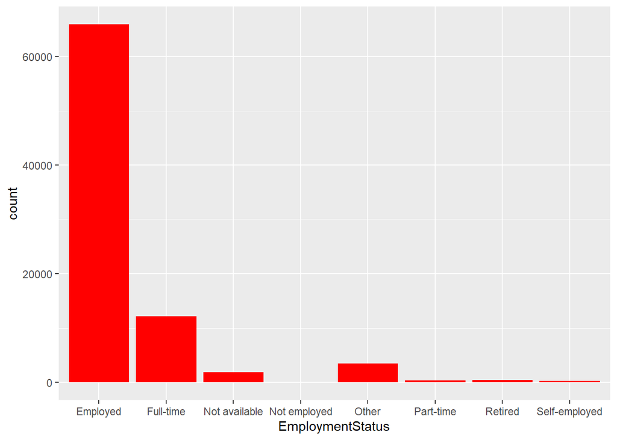

```r
ggplot(data = datos, aes(x = EmploymentStatus)) +
    geom_bar(fill="red")
```

```r
tabla.empleo <- datos %>%
  group_by(EmploymentStatus) %>%
  summarise(count = n(),media=mean(LoanOriginalAmount))

#ordenado por ocurrences
head(tabla.empleo[order(tabla.empleo$count, decreasing=TRUE),],10)
```

```
## # A tibble: 8 x 3
##   EmploymentStatus count media
##   <fct>            <int> <dbl>
## 1 Employed         65894 9864.
## 2 Full-time        12162 5879.
## 3 Other             3526 6942.
## 4 Not available     1889 5258.
## 5 Retired            424 4549.
## 6 Part-time          394 3822.
## 7 Self-employed      254 8979.
## 8 Not employed        33 2794.
```

```r
#ordenado por media de lospréstamos solicitados
head(tabla.empleo[order(tabla.empleo$media, decreasing=TRUE),],10)
```

```
## # A tibble: 8 x 3
##   EmploymentStatus count media
##   <fct>            <int> <dbl>
## 1 Employed         65894 9864.
## 2 Self-employed      254 8979.
## 3 Other             3526 6942.
## 4 Full-time        12162 5879.
## 5 Not available     1889 5258.
## 6 Retired            424 4549.
## 7 Part-time          394 3822.
## 8 Not employed        33 2794.
```

```r
remove(tabla.empleo)
```

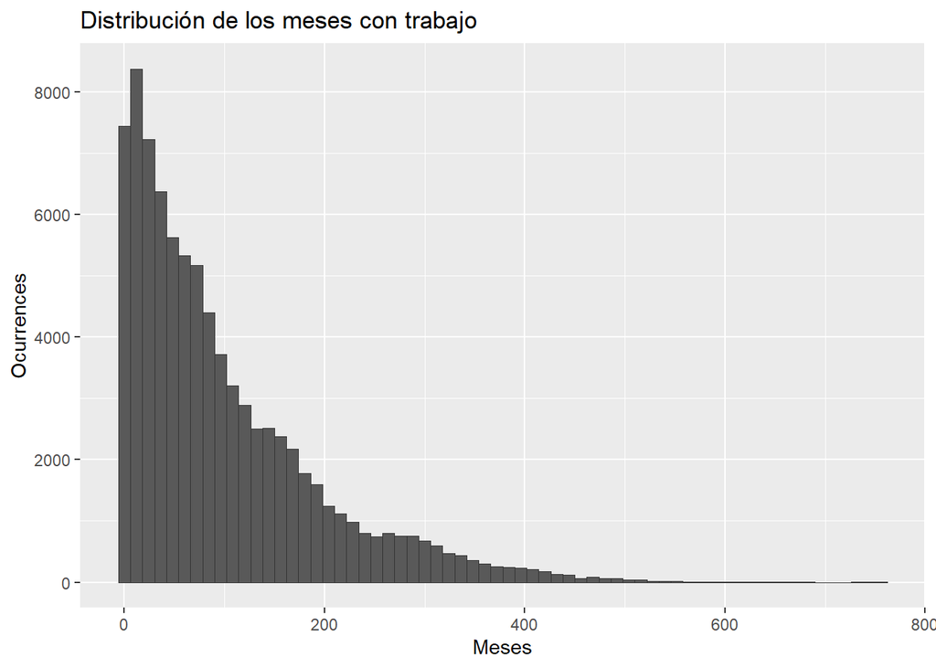

```r
ggplot(aes(x = EmploymentStatusDuration) , data = datos) +
  geom_histogram(aes(), binwidth=12, colour="grey20", lwd=0.2) +
   ggtitle("Distribución de los meses con trabajo") +
  xlab("Meses") + ylab("Ocurrences")
```

Se comprueba que por lo general quienes solicitan préstamos tienen una menor cantidad de tiempo trabajado y Trabajadores por cuenta ajena temporales o indefinidos.

## 5.2 Perfil de préstamos

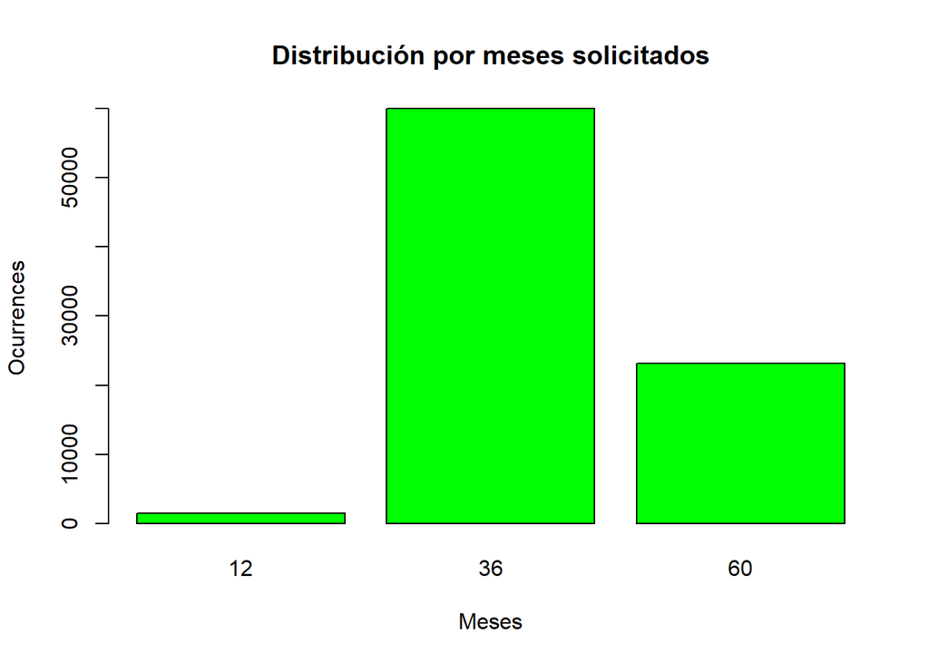

```r
#term
plot(as.factor(datos$Term), main="Distribución por meses solicitados",xlab="Meses", ylab="Ocurrences",col="green")
```

Se observa que de forma mayoritaria se solicitan préstamos a 36 meses.

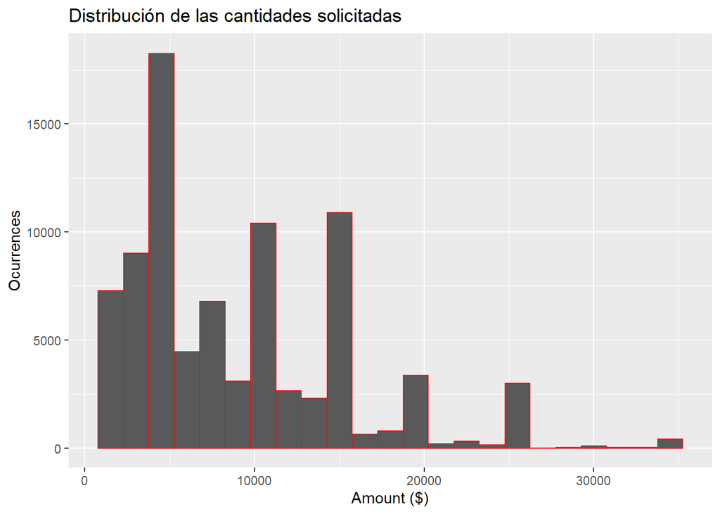

```r
library(ggplot2)

ggplot(aes(x = LoanOriginalAmount ) , data = datos) +
  geom_histogram(aes(), binwidth=1500, colour="red", lwd=0.2) +
   ggtitle("Distribución de las cantidades solicitadas") +
  xlab("Amount ($)") + ylab("Ocurrences")
```

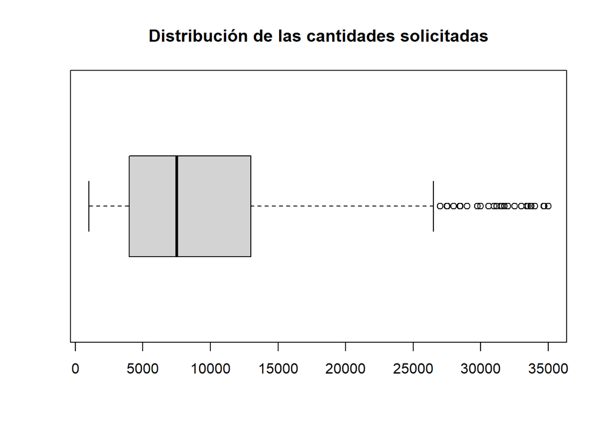

```r
boxplot(datos$LoanOriginalAmount, horizontal = T, main="Distribución de las cantidades solicitadas")
```

Observamos que predominantemente se trata de préstamos por debajo de los 15.000 dólares.

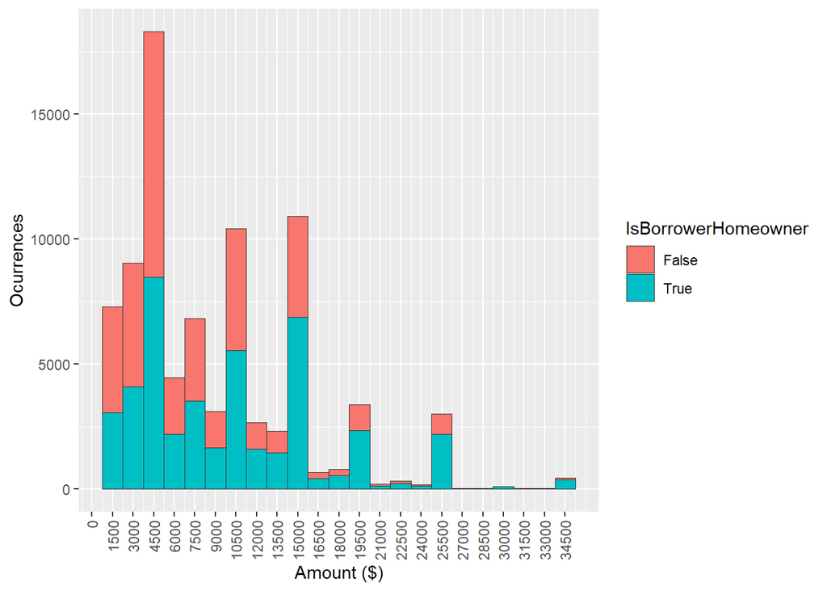

```r
ggplot(aes(x = LoanOriginalAmount ) , data = datos) +
  geom_histogram(aes(fill=IsBorrowerHomeowner), binwidth=1500, colour="grey20", lwd=0.2) +
  scale_x_continuous(breaks=seq(0,max(datos$LoanOriginalAmount), 1500))+
  theme(axis.text.x = element_text(angle = 90, vjust = 0.5, hjust=1))+
  xlab("Amount ($)") + ylab("Ocurrences")
```

Se comprueba como en los préstamos que solicitan mayor cantidad, presenta un mayor porcentaje de propietarios de viviendas.

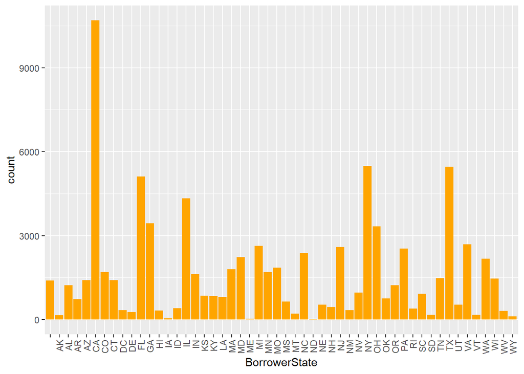

```r
ggplot(data = datos, aes(x = BorrowerState)) +
    geom_bar(fill="orange")+ theme(axis.text.x = element_text(angle = 90, vjust = 0.5, hjust=1))
```

## 5.3 Identificar que préstamos son aquellos en los que más invierten los inversores

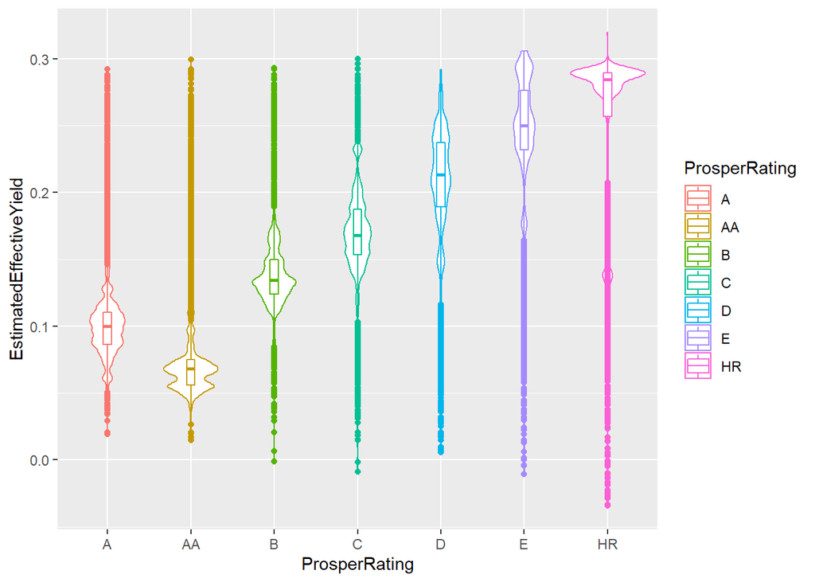

```r
# Basic violin plot
ggplot(datos, aes(x=EstimatedEffectiveYield, y=ProsperRating,color=ProsperRating)) +
  geom_violin()+ coord_flip() + geom_boxplot(width=0.1)
```

Vemos que cuanto peor es el Rating, más rendimiento esperan lograr los inversores.

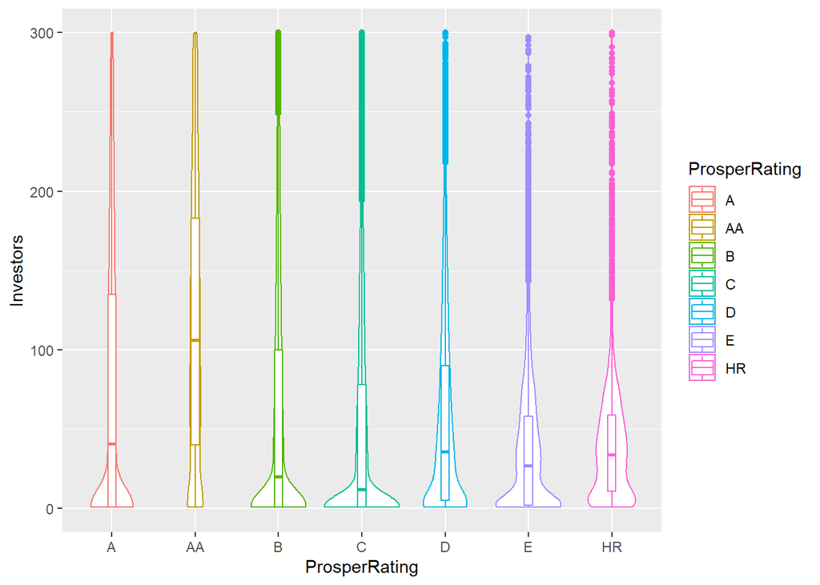

```r
# Basic violin plot
ggplot(datos, aes(x=Investors, y=ProsperRating,color=ProsperRating)) +
  geom_violin()+ coord_flip() + geom_boxplot(width=0.1)+xlim(0,300)
```

Curiosamente, el número de inversores según Rating, de media es menor en las clases de riesgo intermedio, mayor en las de poco riesgo, y medio en las de mayor riesgo.

## 5.4 Otras gráficas de interés

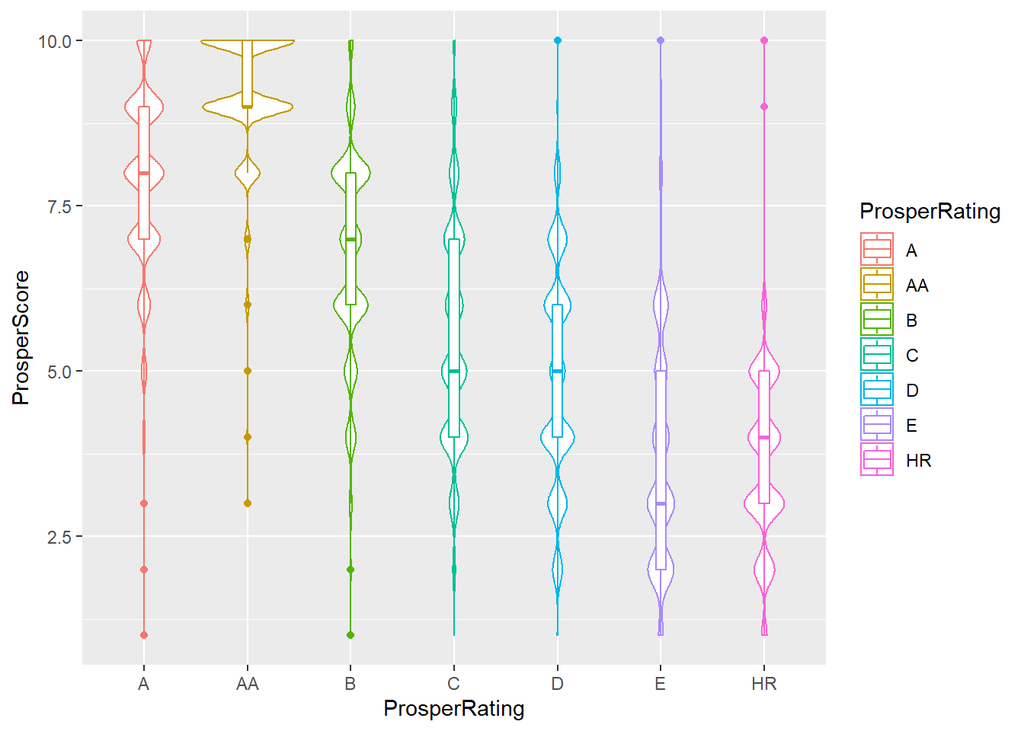

```r
ggplot(datos, aes(x=ProsperScore, y=ProsperRating,color=ProsperRating)) +
     geom_violin()+ coord_flip() + geom_boxplot(width=0.1)
```

Comprobamos como se relaciona el ProsperRating con el ProsperScore. Destaca el hecho de que el ProsperScore medio es inferior en la categoría E que en el nivel HR (High Risk).

# 6 Resolución del problema. A partir de los resultados obtenidos, ¿cuáles son las conclusiones? ¿Los resultados permiten responder al problema?

Hemos escogido un dataset que solo llegar a entender completamente todas las variables recogidas podría requerir todas las horas de dedicación exigidas para la realización de esta práctica, por ello es probable que no hayamos sabido ver todas las posibilidades de explotación que ofrece el dataset en el ámbito de la minería de datos.

En base al conocimiento adquirido, hemos sido capaces de limpiar el dataset y hemos planteado una serie de gráficas y modelos para tratar de responder a las preguntas planteadas.

Hemos conseguido caracterizar gráficamente y/o en tablas los principales atributos que definen a los prestatarios y a los préstamos solicitados. También se ha conseguido identificar el perfil inversor de los prestamistas.

No ha sido posible recrear el cálculo del ProsperScore de manera correcta mediante el uso de un modelo de regresión lineal.

Se ha realizado un contraste de hipótesis para demostrar que el Estado laboral (empleado o desempleado) no afecta de media al ProsperScore.

Se han establecido las reglas que permiten detectar a un buen o mal pagador en base a su perfil económico previo.

Así, ha sido posible responder de una manera adecuada a la mayoría de las preguntas. En el caso de la pregunta que no se ha conseguido responder, se ha planteado de manera correcta la posible solución, si bien el resultado no ha sido positivo. Se requiere otro tipo de herramienta de minería más compleja para resolver esta pregunta.

*Destacar el hecho de que si bien el documento supera las 20 páginas de extensión máxima, esto se debe al código y sus resultados; estando la parte explicativa limitada aproximadamente a dicha extensión.*

# 7 Código

El código se ha presentado en los apartados correspondientes y ha sido comentado de cara a explicar su función y poder entender los resultados.

# 8 Contribución

| Contribuciones | Firma |
| --- | --- |
| Investigación previa | DDO, PMP |
| Redacción de las repuestas | DDO, PMP |
| Desarrollo código | DDO, PMP |